# Comparative Analysis of Supervised Learning Algorithms

## 1. Objective:

The purpose of this project is to explore and complare supervised learning algorithms by applying them to two differnt classidication problems.

## 2. Problem Statements

### 2.1 Wine Quality Prediction

**Problem:** Given the physicochemical test results of a wine, predict whether the quality is wine is above average.

*Why is this problem interesting?*  
**Domain:** Predicting the quality of the wine is crucial while determining its price. It is important to correctly identify above-average wines and hence classifiers must lower False Positive rate. It is acceptable if the classifier has a slightly higher False Negative rate. It will be interesting to see how the classifier implements this constraint.  
**Dataset:** The target variable is the multi-class categorical variable and the only couple of classes are dominant. All the independent variables are numerical and there are no missing values in the dataset. Only a few features are slightly skewed. It will be interesting to see whether supervised learning algorithms show any bias/variance on such a clean dataset.

### 2.2 Income Prediction

**Problem:** Predict whether the income of the individual exceeds 50k a year based on the individual's census data.

**Why is this problem interesting?**  
**Domain:** Predicting the income of an individual has many practical applications across the financial industry. For example, banks can decide whether to approve a loan based on the predicted income of an individual. In such scenarios, it is crucial to lower False Positive rate and it may be acceptable to have a slightly higher False Negative rate. It will be interesting to see how various classifiers implement these constraints.  
**Dataset:** High-level data exploration revealed that many of the independent features are categorical with many classes and some of these are qualitative while others are quantitative. Few of the features are highly skewed. It will be interesting to see how these features impact the performance of supervised algorithms. I also notice the missing values in some of the instances. I will also be interesting to see whether imputing or removing these instances will create any bias in the model

## 3. Datasets

### 3.1 Wine Dataset

UCI Wine Quality dataset consists physicochemical and sensory data red and white variants of the Portuguese "Vinho Verde" wine. Dataset is available at https://archive.ics.uci.edu/ml/datasets/Wine+Quality

Number of Instances: red wine - 1599; white wine - 4898.  
Number of Attributes: 11 + output attribute

Attribute Information Input variables (based on physicochemical tests): 1 - fixed acidity 2 - volatile acidity 3 - citric acid 4 - residual sugar 5 - chlorides 6 - free sulfur dioxide 7 - total sulfur dioxide 8 - density 9 - pH 10 - sulphates 11 - alcohol  
Output variable (based on sensory data): 12 - quality (score between 0 and 10)

### 3.1 Census Dataset

Dataset was extracted by Barry Becker from the 1994 Census database. A set of reasonably clean records was extracted using the following conditions: ((AAGE>16) && (AGI>100) && (AFNLWGT>1)&& (HRSWK>0)). Dataset is available at https://archive.ics.uci.edu/ml/datasets/Census+Income

Number of Instances: 48842  
Number of Attributes: 14 + output attribute

Attribute Information: Input Variables: 1 - age 2 - workclass 3- fnlwgt 4 - education 5 - education-num 6 - marital-status 7- occupation 8 - relationship 9 - race 10 - sex 11 - capital-gain 12 - capital-loss 13 - hours-per-week 14 - native-country  
Output Variable: 15 - income

## 4. Exploratory Data Analysis & Preprocessing

```python
#Packages Used
import pandas as pd
import numpy as np
import utils
import time
import matplotlib.pyplot as plt
import seaborn as sns
from sklearn import preprocessing
from sklearn import tree
from sklearn.ensemble import ExtraTreesClassifier
from sklearn.preprocessing import StandardScaler
from sklearn.model_selection import StratifiedKFold, train_test_split, cross_val_predict, cross_val_score, GridSearchCV
from sklearn.tree import DecisionTreeClassifier
from sklearn.neighbors import KNeighborsClassifier
from sklearn.dummy import DummyClassifier
from sklearn.svm import SVC
from sklearn.neural_network import MLPClassifier
from sklearn.ensemble import AdaBoostClassifier

from sklearn.model_selection import cross_val_score
from sklearn.metrics import classification_report
from sklearn.metrics import average_precision_score, precision_recall_curve

from sklearn.metrics import confusion_matrix
from sklearn.metrics import accuracy_score, precision_score, recall_score, f1_score
# from sklearn.metrics import , make_scorer
# from sklearn.metrics import precision_recall_curve, auc, roc_curve, roc_auc_score
%matplotlib inline
```

### 4.1 Wine Dataset

```python
#load red wine dataset
dataset_loc_red = "./datasets/wine/winequality-red.csv"
df_red = pd.read_csv(dataset_loc_red, sep=";")

#load white wine dataset
dataset_loc_white = "./datasets/wine/winequality-white.csv"
df_white = pd.read_csv(dataset_loc_white, sep=";")

#combine both datasets
df_combined = df_red.append(df_white, ignore_index=True)
df_combined.head()
```

|  | fixed acidity | volatile acidity | citric acid | residual sugar | chlorides | free sulfur dioxide | total sulfur dioxide | density | pH | sulphates | alcohol | quality |
| --- | --- | --- | --- | --- | --- | --- | --- | --- | --- | --- | --- | --- |
| 0 | 7.4 | 0.70 | 0.00 | 1.9 | 0.076 | 11.0 | 34.0 | 0.9978 | 3.51 | 0.56 | 9.4 | 5 |
| 1 | 7.8 | 0.88 | 0.00 | 2.6 | 0.098 | 25.0 | 67.0 | 0.9968 | 3.20 | 0.68 | 9.8 | 5 |
| 2 | 7.8 | 0.76 | 0.04 | 2.3 | 0.092 | 15.0 | 54.0 | 0.9970 | 3.26 | 0.65 | 9.8 | 5 |
| 3 | 11.2 | 0.28 | 0.56 | 1.9 | 0.075 | 17.0 | 60.0 | 0.9980 | 3.16 | 0.58 | 9.8 | 6 |
| 4 | 7.4 | 0.70 | 0.00 | 1.9 | 0.076 | 11.0 | 34.0 | 0.9978 | 3.51 | 0.56 | 9.4 | 5 |

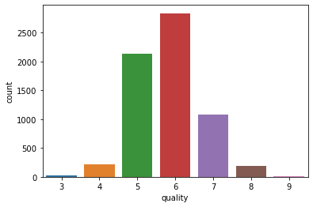

```python
#Ploting the class distribution
sns.countplot(x='quality', data = df_combined);
```

Note that class distribution is not equal and it is instead biased towards 5 and 6. Slight imbalance can be treated like a normal classification predictive modeling problem. Unfortunately in this dataset, we observe Severe imbalance. The classifier will be biased towards the Majority class but it will ignore minority classes such as 4, 8, 9, etc.  
Since our goal is to predict whether wine quality above and to get rid of the imbalanced class problem, we will convert this into a binary classification problem. If the quality of the wine is > 5, then the wine is above average If the quality of the wine is <= 5, then the wine is below average.

```python
# Categorize wine into "above average" and "below average" wines
df_combined["quality"].values[df_combined["quality"] <= 5] = 0
df_combined["quality"].values[df_combined["quality"] > 5] = 1
```

```python
# check for missing values
df_combined.isnull().values.any()
```

```
False
```

```python
# check for feature data types
df_combined.info()
```

```
<class 'pandas.core.frame.DataFrame'>
RangeIndex: 6497 entries, 0 to 6496
Data columns (total 12 columns):
fixed acidity           6497 non-null float64
volatile acidity        6497 non-null float64
citric acid             6497 non-null float64
residual sugar          6497 non-null float64
chlorides               6497 non-null float64
free sulfur dioxide     6497 non-null float64
total sulfur dioxide    6497 non-null float64
density                 6497 non-null float64
pH                      6497 non-null float64
sulphates               6497 non-null float64
alcohol                 6497 non-null float64
quality                 6497 non-null int64
dtypes: float64(11), int64(1)
memory usage: 609.2 KB
```

```python
#Analyze Features
df_combined.describe()
```

|  | fixed acidity | volatile acidity | citric acid | residual sugar | chlorides | free sulfur dioxide | total sulfur dioxide | density | pH | sulphates | alcohol | quality |
| --- | --- | --- | --- | --- | --- | --- | --- | --- | --- | --- | --- | --- |
| count | 6497.000000 | 6497.000000 | 6497.000000 | 6497.000000 | 6497.000000 | 6497.000000 | 6497.000000 | 6497.000000 | 6497.000000 | 6497.000000 | 6497.000000 | 6497.000000 |
| mean | 7.215307 | 0.339666 | 0.318633 | 5.443235 | 0.056034 | 30.525319 | 115.744574 | 0.994697 | 3.218501 | 0.531268 | 10.491801 | 0.633061 |
| std | 1.296434 | 0.164636 | 0.145318 | 4.757804 | 0.035034 | 17.749400 | 56.521855 | 0.002999 | 0.160787 | 0.148806 | 1.192712 | 0.482007 |
| min | 3.800000 | 0.080000 | 0.000000 | 0.600000 | 0.009000 | 1.000000 | 6.000000 | 0.987110 | 2.720000 | 0.220000 | 8.000000 | 0.000000 |
| 25% | 6.400000 | 0.230000 | 0.250000 | 1.800000 | 0.038000 | 17.000000 | 77.000000 | 0.992340 | 3.110000 | 0.430000 | 9.500000 | 0.000000 |
| 50% | 7.000000 | 0.290000 | 0.310000 | 3.000000 | 0.047000 | 29.000000 | 118.000000 | 0.994890 | 3.210000 | 0.510000 | 10.300000 | 1.000000 |
| 75% | 7.700000 | 0.400000 | 0.390000 | 8.100000 | 0.065000 | 41.000000 | 156.000000 | 0.996990 | 3.320000 | 0.600000 | 11.300000 | 1.000000 |
| max | 15.900000 | 1.580000 | 1.660000 | 65.800000 | 0.611000 | 289.000000 | 440.000000 | 1.038980 | 4.010000 | 2.000000 | 14.900000 | 1.000000 |

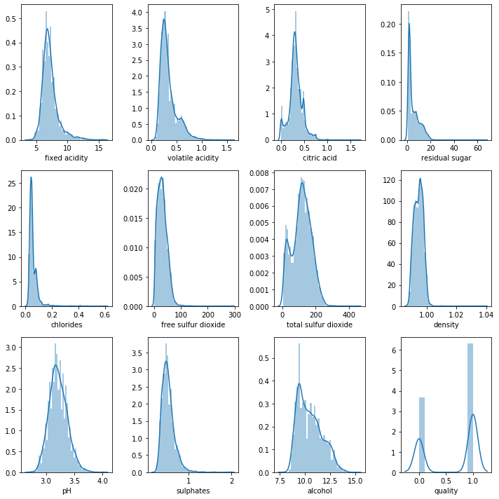

```python
# plot feature distribution

fig, axs = plt.subplots(nrows=3, ncols=4, figsize=(10,10));
sns.distplot(df_combined['fixed acidity'], ax=axs[0,0])
sns.distplot(df_combined['volatile acidity'], ax=axs[0,1])
sns.distplot(df_combined['citric acid'], ax=axs[0,2])
sns.distplot(df_combined['residual sugar'], ax=axs[0,3])
sns.distplot(df_combined['chlorides'], ax=axs[1,0])
sns.distplot(df_combined['free sulfur dioxide'], ax=axs[1,1])
sns.distplot(df_combined['total sulfur dioxide'], ax=axs[1,2])
sns.distplot(df_combined['density'], ax=axs[1,3])
sns.distplot(df_combined['pH'], ax=axs[2,0])
sns.distplot(df_combined['sulphates'], ax=axs[2,1])
sns.distplot(df_combined['alcohol'], ax=axs[2,2])
sns.distplot(df_combined['quality'], ax=axs[2,3])
plt.tight_layout()
```

```python
# # remove outliers
# outliers_df_combined = pd.DataFrame()

# for feature in df_combined.iloc[:,:-1].keys():
#     Q1 = np.percentile(df_combined[feature], q=25)
#     Q3 = np.percentile(df_combined[feature], q=75)
#     interquartile_range = Q3 - Q1
#     step = 1.5 * interquartile_range
#     outliers_df_combined = outliers_df_combined.append(df_combined[~((df_combined[feature] >= Q1 - step) & (df_combined[feature] <= Q3 + step))])

# df_combined = df_combined.drop(df_combined.index[outliers_df_combined.index]).reset_index(drop = True)
```

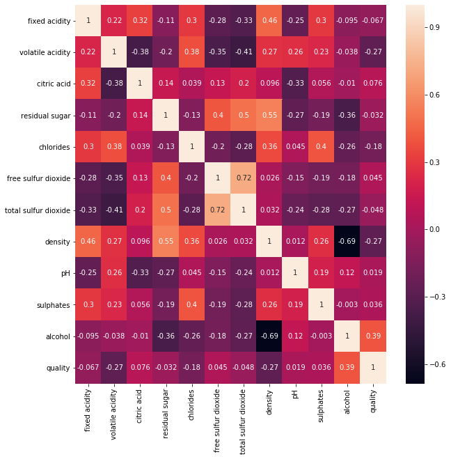

```python
#plot correlation heat map
plt.figure(figsize =(10,10))
sns.heatmap(df_combined.corr(),annot=True)
plt.show()
```

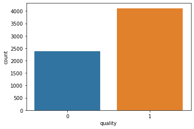

```python
#Ploting the class distribution
sns.countplot(x='quality', data = df_combined);
```

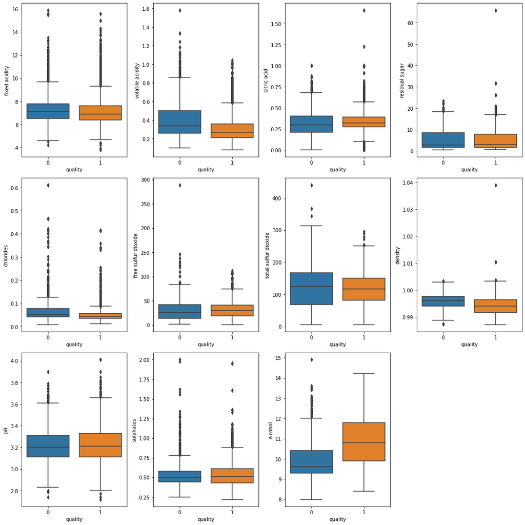

```python
fig, axs = plt.subplots(nrows=3, ncols=4, figsize=(15,15));
sns.boxplot(df_combined['quality'],df_combined['fixed acidity'], ax=axs[0,0])
sns.boxplot(df_combined['quality'],df_combined['volatile acidity'], ax=axs[0,1])
sns.boxplot(df_combined['quality'],df_combined['citric acid'], ax=axs[0,2])
sns.boxplot(df_combined['quality'],df_combined['residual sugar'], ax=axs[0,3])
sns.boxplot(df_combined['quality'],df_combined['chlorides'], ax=axs[1,0])
sns.boxplot(df_combined['quality'],df_combined['free sulfur dioxide'], ax=axs[1,1])
sns.boxplot(df_combined['quality'],df_combined['total sulfur dioxide'], ax=axs[1,2])
sns.boxplot(df_combined['quality'],df_combined['density'], ax=axs[1,3])
sns.boxplot(df_combined['quality'],df_combined['pH'], ax=axs[2,0])
sns.boxplot(df_combined['quality'],df_combined['sulphates'], ax=axs[2,1])
sns.boxplot(df_combined['quality'],df_combined['alcohol'], ax=axs[2,2])
fig.delaxes(axs[2,3])
plt.tight_layout()
```

```python
Wine_X = df_combined.iloc[:,:-1]
Wine_y = df_combined.iloc[:,-1]
```

```python
# Split the data into a training set and a test set
Wine_X_train, Wine_X_test, Wine_y_train, Wine_y_test = train_test_split(Wine_X, Wine_y, random_state=1, test_size=0.30)
```

```python
scaler = StandardScaler()
Wine_X_train = scaler.fit_transform(Wine_X_train)
Wine_X_test = scaler.transform(Wine_X_test)
```

### 4.2 Census Dataset

```python
#load census dataset
colnames=['age', 'workclass', 'fnlwgt', 'education', 'education-num', 'marital-status', 'occupation', 'relationship', 'race', 'sex', 'capital-gain', 'capital-loss', 'hours-per-week', 'native-country', 'income']
dataset_loc = "./datasets/census/adult.data"
df_census = pd.read_csv(dataset_loc, names=colnames, header=None, skipinitialspace=True)
df_census.shape
```

```
(32561, 15)
```

```python
# check for missing values
df_census.isnull().values.any()
```

```
False
```

```python
# check for feature data types
df_census.info()
```

```
<class 'pandas.core.frame.DataFrame'>
RangeIndex: 32561 entries, 0 to 32560
Data columns (total 15 columns):
age               32561 non-null int64
workclass         32561 non-null object
fnlwgt            32561 non-null int64
education         32561 non-null object
education-num     32561 non-null int64
marital-status    32561 non-null object
occupation        32561 non-null object
relationship      32561 non-null object
race              32561 non-null object
sex               32561 non-null object
capital-gain      32561 non-null int64
capital-loss      32561 non-null int64
hours-per-week    32561 non-null int64
native-country    32561 non-null object
income            32561 non-null object
dtypes: int64(6), object(9)
memory usage: 3.7+ MB
```

```python
#Analyze Features
df_census.describe()
```

|  | age | fnlwgt | education-num | capital-gain | capital-loss | hours-per-week |
| --- | --- | --- | --- | --- | --- | --- |
| count | 32561.000000 | 3.256100e+04 | 32561.000000 | 32561.000000 | 32561.000000 | 32561.000000 |
| mean | 38.581647 | 1.897784e+05 | 10.080679 | 1077.648844 | 87.303830 | 40.437456 |
| std | 13.640433 | 1.055500e+05 | 2.572720 | 7385.292085 | 402.960219 | 12.347429 |
| min | 17.000000 | 1.228500e+04 | 1.000000 | 0.000000 | 0.000000 | 1.000000 |
| 25% | 28.000000 | 1.178270e+05 | 9.000000 | 0.000000 | 0.000000 | 40.000000 |
| 50% | 37.000000 | 1.783560e+05 | 10.000000 | 0.000000 | 0.000000 | 40.000000 |
| 75% | 48.000000 | 2.370510e+05 | 12.000000 | 0.000000 | 0.000000 | 45.000000 |
| max | 90.000000 | 1.484705e+06 | 16.000000 | 99999.000000 | 4356.000000 | 99.000000 |

```python
# Replace missing values "?" with NAs
df_census.replace('?', np.nan, inplace=True)
df_census.dropna()
```

|  | age | workclass | fnlwgt | education | education-num | marital-status | occupation | relationship | race | sex | capital-gain | capital-loss | hours-per-week | native-country | income |
| --- | --- | --- | --- | --- | --- | --- | --- | --- | --- | --- | --- | --- | --- | --- | --- |
| 0 | 39 | State-gov | 77516 | Bachelors | 13 | Never-married | Adm-clerical | Not-in-family | White | Male | 2174 | 0 | 40 | United-States | <=50K |
| 1 | 50 | Self-emp-not-inc | 83311 | Bachelors | 13 | Married-civ-spouse | Exec-managerial | Husband | White | Male | 0 | 0 | 13 | United-States | <=50K |
| 2 | 38 | Private | 215646 | HS-grad | 9 | Divorced | Handlers-cleaners | Not-in-family | White | Male | 0 | 0 | 40 | United-States | <=50K |
| 3 | 53 | Private | 234721 | 11th | 7 | Married-civ-spouse | Handlers-cleaners | Husband | Black | Male | 0 | 0 | 40 | United-States | <=50K |
| 4 | 28 | Private | 338409 | Bachelors | 13 | Married-civ-spouse | Prof-specialty | Wife | Black | Female | 0 | 0 | 40 | Cuba | <=50K |
| ... | ... | ... | ... | ... | ... | ... | ... | ... | ... | ... | ... | ... | ... | ... | ... |
| 32556 | 27 | Private | 257302 | Assoc-acdm | 12 | Married-civ-spouse | Tech-support | Wife | White | Female | 0 | 0 | 38 | United-States | <=50K |
| 32557 | 40 | Private | 154374 | HS-grad | 9 | Married-civ-spouse | Machine-op-inspct | Husband | White | Male | 0 | 0 | 40 | United-States | >50K |
| 32558 | 58 | Private | 151910 | HS-grad | 9 | Widowed | Adm-clerical | Unmarried | White | Female | 0 | 0 | 40 | United-States | <=50K |
| 32559 | 22 | Private | 201490 | HS-grad | 9 | Never-married | Adm-clerical | Own-child | White | Male | 0 | 0 | 20 | United-States | <=50K |
| 32560 | 52 | Self-emp-inc | 287927 | HS-grad | 9 | Married-civ-spouse | Exec-managerial | Wife | White | Female | 15024 | 0 | 40 | United-States | >50K |

30162 rows × 15 columns

```python
df_census.isnull().sum(axis = 0)
```

```
age                  0
workclass         1836
fnlwgt               0
education            0
education-num        0
marital-status       0
occupation        1843
relationship         0
race                 0
sex                  0
capital-gain         0
capital-loss         0
hours-per-week       0
native-country     583
income               0
dtype: int64
```

```python
df_census.dropna(axis=0, inplace=True)
```

```python
# converting target variable.
# df_census['income'] = df_census['income'].apply(lambda x: 1 if x=='>50K' else 0)
df_census["income"].values[df_census["income"] == '<=50K'] = 0
df_census["income"].values[df_census["income"] == '>50K'] = 1
```

```python
#Feature Encoding
le = preprocessing.LabelEncoder()

for i in range(0,df_census.shape[1]):
    if df_census.dtypes[i]=='object':
        df_census[df_census.columns[i]] = le.fit_transform(df_census[df_census.columns[i]])
```

```python
df_census.corr()
```

|  | age | workclass | fnlwgt | education | education-num | marital-status | occupation | relationship | race | sex | capital-gain | capital-loss | hours-per-week | native-country | income |
| --- | --- | --- | --- | --- | --- | --- | --- | --- | --- | --- | --- | --- | --- | --- | --- |
| age | 1.000000 | 0.080540 | -0.076511 | -0.001111 | 0.043526 | -0.276373 | -0.005682 | -0.246456 | 0.023374 | 0.081993 | 0.080154 | 0.060165 | 0.101599 | -0.001905 | 0.241998 |
| workclass | 0.080540 | 1.000000 | -0.032493 | 0.017855 | 0.037833 | -0.034241 | 0.015572 | -0.067417 | 0.044731 | 0.074973 | 0.035350 | 0.007204 | 0.050724 | 0.007668 | 0.018044 |
| fnlwgt | -0.076511 | -0.032493 | 1.000000 | -0.027102 | -0.044992 | 0.032163 | 0.000204 | 0.009298 | -0.023895 | 0.025362 | 0.000422 | -0.009750 | -0.022886 | -0.066717 | -0.008957 |
| education | -0.001111 | 0.017855 | -0.027102 | 1.000000 | 0.345410 | -0.040664 | -0.038212 | -0.012717 | 0.011154 | -0.027888 | 0.030575 | 0.015028 | 0.059887 | 0.078790 | 0.078987 |
| education-num | 0.043526 | 0.037833 | -0.044992 | 0.345410 | 1.000000 | -0.063419 | 0.087717 | -0.091935 | 0.032805 | 0.006157 | 0.124416 | 0.079646 | 0.152522 | 0.091555 | 0.335286 |
| marital-status | -0.276373 | -0.034241 | 0.032163 | -0.040664 | -0.063419 | 1.000000 | 0.022655 | 0.177964 | -0.068627 | -0.119813 | -0.042418 | -0.035203 | -0.189003 | -0.025902 | -0.193518 |
| occupation | -0.005682 | 0.015572 | 0.000204 | -0.038212 | 0.087717 | 0.022655 | 1.000000 | -0.053727 | 0.000717 | 0.062313 | 0.022162 | 0.014607 | 0.018365 | -0.003483 | 0.051577 |
| relationship | -0.246456 | -0.067417 | 0.009298 | -0.012717 | -0.091935 | 0.177964 | -0.053727 | 1.000000 | -0.117143 | -0.584876 | -0.058259 | -0.063567 | -0.257850 | -0.010809 | -0.251003 |
| race | 0.023374 | 0.044731 | -0.023895 | 0.011154 | 0.032805 | -0.068627 | 0.000717 | -0.117143 | 1.000000 | 0.089186 | 0.014353 | 0.023517 | 0.048532 | 0.124514 | 0.071658 |
| sex | 0.081993 | 0.074973 | 0.025362 | -0.027888 | 0.006157 | -0.119813 | 0.062313 | -0.584876 | 0.089186 | 1.000000 | 0.048814 | 0.047011 | 0.231268 | 0.000618 | 0.216699 |
| capital-gain | 0.080154 | 0.035350 | 0.000422 | 0.030575 | 0.124416 | -0.042418 | 0.022162 | -0.058259 | 0.014353 | 0.048814 | 1.000000 | -0.032229 | 0.080432 | 0.008530 | 0.221196 |
| capital-loss | 0.060165 | 0.007204 | -0.009750 | 0.015028 | 0.079646 | -0.035203 | 0.014607 | -0.063567 | 0.023517 | 0.047011 | -0.032229 | 1.000000 | 0.052417 | 0.009386 | 0.150053 |
| hours-per-week | 0.101599 | 0.050724 | -0.022886 | 0.059887 | 0.152522 | -0.189003 | 0.018365 | -0.257850 | 0.048532 | 0.231268 | 0.080432 | 0.052417 | 1.000000 | 0.008408 | 0.229480 |
| native-country | -0.001905 | 0.007668 | -0.066717 | 0.078790 | 0.091555 | -0.025902 | -0.003483 | -0.010809 | 0.124514 | 0.000618 | 0.008530 | 0.009386 | 0.008408 | 1.000000 | 0.023268 |
| income | 0.241998 | 0.018044 | -0.008957 | 0.078987 | 0.335286 | -0.193518 | 0.051577 | -0.251003 | 0.071658 | 0.216699 | 0.221196 | 0.150053 | 0.229480 | 0.023268 | 1.000000 |

```python
# droping fnlwgt columns as it is not relevant. Also droping education column as it is highly corelated with education-num column.
df_census=df_census.drop(['fnlwgt','education'], axis=1)
```

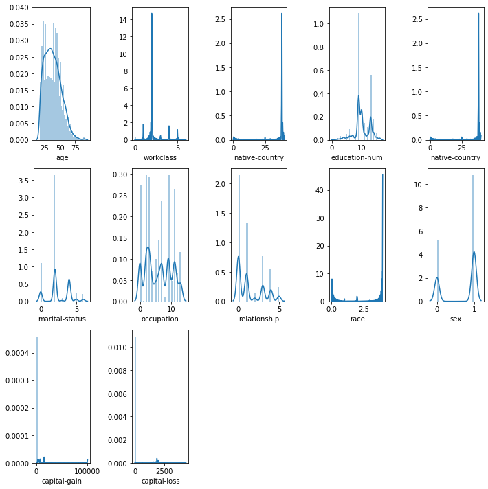

```python
# plot feature distribution

fig, axs = plt.subplots(nrows=3, ncols=5, figsize=(10,10));
sns.distplot(df_census['age'], ax=axs[0,0])
sns.distplot(df_census['workclass'], ax=axs[0,1])
sns.distplot(df_census['native-country'], ax=axs[0,2])
sns.distplot(df_census['education-num'], ax=axs[0,3])
sns.distplot(df_census['native-country'], ax=axs[0,4])
sns.distplot(df_census['marital-status'], ax=axs[1,0])
sns.distplot(df_census['occupation'], ax=axs[1,1])
sns.distplot(df_census['relationship'], ax=axs[1,2])
sns.distplot(df_census['race'], ax=axs[1,3])
sns.distplot(df_census['sex'], ax=axs[1,4])
sns.distplot(df_census['capital-gain'], ax=axs[2,0])
sns.distplot(df_census['capital-loss'], ax=axs[2,1])
fig.delaxes(axs[2,2])
fig.delaxes(axs[2,3])
fig.delaxes(axs[2,4])
plt.tight_layout()
```

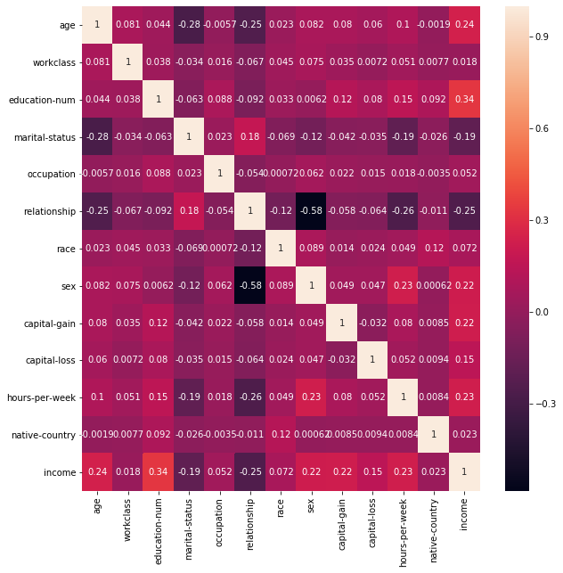

```python
#Plot correlation heat map
plt.figure(figsize =(10,10))
sns.heatmap(df_census.corr(),annot=True)
plt.show()
```

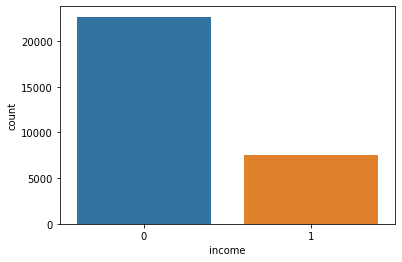

```python
#Ploting the class distribution
sns.countplot(x='income', data = df_census);
```

```python
# # remove outliers
# outliers_df_census = pd.DataFrame()

# for feature in df_census.iloc[:,:-1].keys():
#     Q1 = np.percentile(df_census[feature], q=25)
#     Q3 = np.percentile(df_census[feature], q=75)
#     interquartile_range = Q3 - Q1
#     step = 1.5 * interquartile_range
#     outliers_df_census = outliers_df_census.append(df_census[~((df_census[feature] >= Q1 - step) & (df_census[feature] <= Q3 + step))])

# df_census = df_census.drop(df_census.index[outliers_df_census.index]).reset_index(drop = True)
```

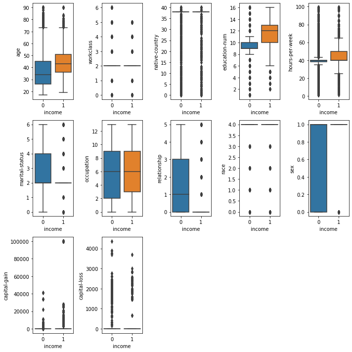

```python
fig, axs = plt.subplots(nrows=3, ncols=5, figsize=(10,10));
sns.boxplot(df_census['income'],df_census['age'], ax=axs[0,0])
sns.boxplot(df_census['income'],df_census['workclass'], ax=axs[0,1])
sns.boxplot(df_census['income'],df_census['native-country'], ax=axs[0,2])
sns.boxplot(df_census['income'],df_census['education-num'], ax=axs[0,3])
sns.boxplot(df_census['income'],df_census['hours-per-week'], ax=axs[0,4])
sns.boxplot(df_census['income'],df_census['marital-status'], ax=axs[1,0])
sns.boxplot(df_census['income'],df_census['occupation'], ax=axs[1,1])
sns.boxplot(df_census['income'],df_census['relationship'], ax=axs[1,2])
sns.boxplot(df_census['income'],df_census['race'], ax=axs[1,3])
sns.boxplot(df_census['income'],df_census['sex'], ax=axs[1,4])
sns.boxplot(df_census['income'],df_census['capital-gain'], ax=axs[2,0])
sns.boxplot(df_census['income'],df_census['capital-loss'], ax=axs[2,1])
fig.delaxes(axs[2,2])
fig.delaxes(axs[2,3])
fig.delaxes(axs[2,4])
plt.tight_layout()
```

```python
Census_X = df_census.iloc[:,:-1]
Census_y = df_census.iloc[:,-1]
```

```python
# Split the data into a training set and a test set
Census_X_train, Census_X_test, Census_y_train, Census_y_test = train_test_split(Census_X, Census_y, random_state=1, test_size=0.30)
```

```python
scaler = StandardScaler()
Census_X_train = scaler.fit_transform(Census_X_train)
Census_X_test = scaler.transform(Census_X_test)
```

**Class Distribution:** Class distribution in both datasets was imbalanced. Wine quality dataset had multiple classes ranging from 3 to 9 but only class 5, 6 and 7 had majority of data. Since our goal is to predict whether wine quality above average, target variable converted to binary. If the quality of the wine is > 5, then the wine is above average (i.e. 1) and if the quality of the wine is <= 5, then the wine is below average (i.e. 0). After this conversion wine quality dataset was still imbalanced. Similarly Census dataset was also imbalanced but none of these two datasets were extremely imbalanced (i.e. 10:1).  
**Missing Data:** Wine dataset was clean without any missing data. Census dataset had missing fields in 3 columns. Rows with missing values were removed because the number of rows were less and imputing categorical variable to mode may introduce bias.  
**Outliers:** Outliers were observed in both datasets which were initially removed using Tukey's method. It was observed that F1 score for all algorithms dropped (3-5%) after removing outliers from the dataset. I learnt that it is not a good practice to just remove the data points because they lie outside the IQR. Only after detailed understanding of domain we can draw possible ranges for each feature variables. These ranges can then be used to remove true outliers. Also tree based algorithms are insensitive to outliers. Hence outliers are not removed for this project due to lack of domain understanding. Finally approach to remove outliers was not implemented for both datasets.  
**Feature Scaling:** For both datasets it was observe that features vary widely in their magnitudes. Features were scaled using StandardScaler to improve the training time of the distance and similarity-based algorithm. Tree-based algorithms are insensitive to feature scaling. Nonetheless we will scale the features of both dataset as it will help in visualizing the data and comparing performance of different algorithms.